# Week 6 Data Dive - Confidence Intervals

Raghuveer Venkatesh

2024-10-09

## Introduction

In this RMarkdown notebook, we’ll explore relationships between pairs of numbers in the data, focusing on how one might affect the other. We will then plot a relationship between the two pairs and then draw conclusions based on the observation. Finally, we will calculate the correlation co-efficient between the these combinations and build a confidence interval for each of the response variables.

## Building our pairs

### Pair 1: Value in Euros vs. Overall Rating

This new variable shows the value per unit of rating, helping to explore how much market value each rating point represents.

```r
# Create the 'value_per_rating' column
player_data$value_per_rating <- player_data$value_euro / player_data$overall_rating
head(player_data$value_per_rating)
```

```
## [1] 1175531.9  789772.7  829545.5  704545.5  681818.2  676136.4
```

### Explaination

In this pair, we treat market value (value_euro) as the response variable and the overall ratings the explanatory variable to investigate how a player’s rating impacts their market value.

## Pair 2: Stamina vs. Strength

This new variable shows the ratio of stamina to strength, indicating how balanced the player’s endurance is compared to their strength.

```r
# Create the 'endurance_to_strength_ratio' column
player_data$endurance_to_strength_ratio <- player_data$stamina / player_data$strength
head(player_data$endurance_to_strength_ratio)
```

```
## [1] 1.0909091 1.5862069 1.0114943 1.7045455 0.7978723 0.8152174
```

### Explaination

This new variable represents the ratio between stamina and strength. It tells us how much endurance a player has in relation to their strength. A higher ratio indicates that a player has relatively more stamina compared to their physical strength, while a lower ratio suggests that their strength is more dominant over endurance. This is useful for determining the position a player can play in.

## Plotting the pairs to find the outliers

### Plot Pair 1: Value in Euros vs. Overall Rating

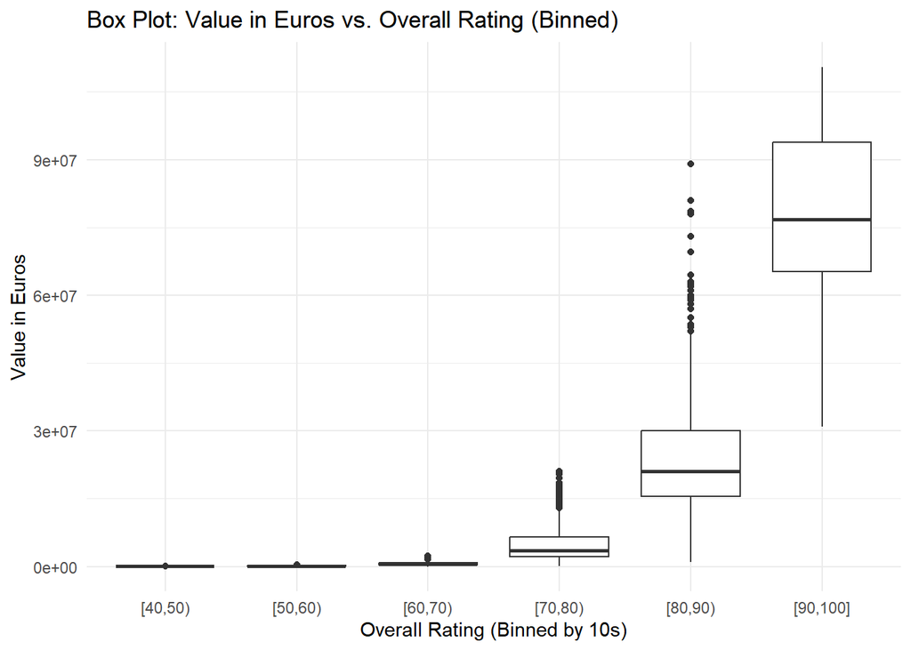

```r
# Bin overall_rating and strength into intervals of 10 (10-20, 20-30, ..., 90-100)
player_data$overall_rating_bin <- cut(player_data$overall_rating,
                                      breaks = seq(10, 100, by = 10),
                                      include.lowest = TRUE,
                                      right = FALSE) # Left-inclusive intervals

player_data$strength_bin <- cut(player_data$strength,
                                breaks = seq(10, 100, by = 10),
                                include.lowest = TRUE,
                                right = FALSE)

# Create a box plot for Value in Euros vs. Overall Rating
ggplot(player_data, aes(x = overall_rating_bin, y = value_euro)) +
  geom_boxplot() +
  labs(title = "Box Plot: Value in Euros vs. Overall Rating (Binned)",
       x = "Overall Rating (Binned by 10s)",
       y = "Value in Euros") +
  theme_minimal()
```

### Observations

These are players with much higher market value than expected for their rating. Possible reasons for this maybe that they are young players with high potential driving up their value even though their overall rating is lower.

### Plot Pair 2: Stamina vs. Strength

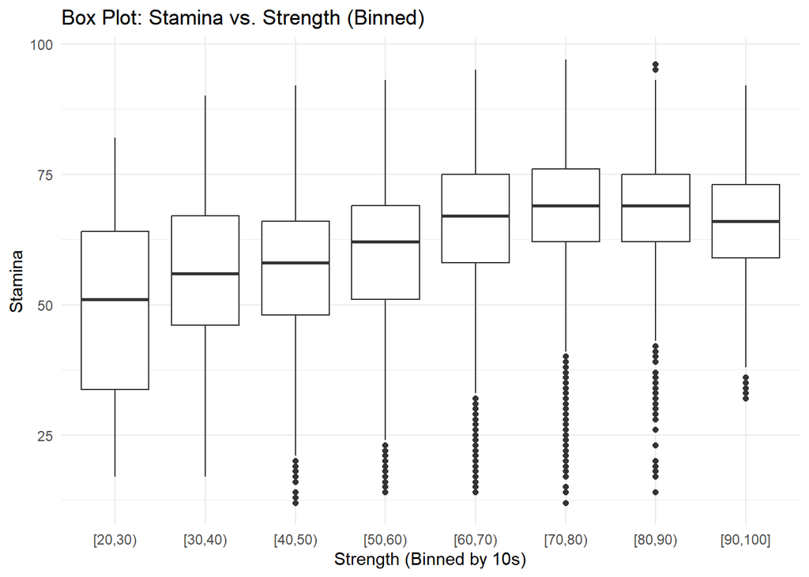

```r
ggplot(player_data, aes(x = strength_bin, y = stamina)) +
  geom_boxplot() +
  labs(title = "Box Plot: Stamina vs. Strength (Binned)",
       x = "Strength (Binned by 10s)",
       y = "Stamina") +
  theme_minimal()
```

### observations

There are few players with significantly high stamina compared to their peers in the same strength group but we mostly observe that there are a lot of players with lower stamina at the same strength range compared to their peers. This might be because they might be older players who have retained their strength but their stamina has dropped.

## Calculating Pearson’s correlation co-efficient for these pairs

### Pearson’s co-efficient for Pair 1: Value in Euros vs. Overall Rating

```r
# Calculating the correlation for Pair 1: value_euro vs. overall_rating
cor_value_rating <- cor(player_data$value_euro, player_data$overall_rating, use = "complete.obs")
cat("Correlation between value_euro and overall_rating:", cor_value_rating, "\n")
```

```
## Correlation between value_euro and overall_rating: 0.6309281
```

### Observations

This correlation is expected to be positive and relatively strong, since a higher overall rating generally corresponds to a higher market value for a player. This is logical because players with better skills and performances are more valuable in the transfer market.

```r
# Calculating the correlation for Pair 2: stamina vs. strength
cor_stamina_strength <- cor(player_data$stamina, player_data$strength, use = "complete.obs")
cat("Correlation between stamina and strength:", cor_stamina_strength, "\n")
```

```
## Correlation between stamina and strength: 0.2671001
```

### Observations

This correlation is expected to be positive, but possibly weaker than the first pair. Although strength and stamina are both physical attributes, they measure different aspects of a player’s fitness. Some players might have high stamina but moderate strength, or vice versa, depending on their position or training focus.

## Confidence intervals for this data

```r
# 95% Confidence Interval for value_euro (Response Variable 1)
ci_value_euro <- t.test(player_data$value_euro)$conf.int

# 95% Confidence Interval for stamina (Response Variable 2)
ci_stamina <- t.test(player_data$stamina)$conf.int

# Display the results
cat("95% Confidence Interval for value_euro:", ci_value_euro, "\n")
```

```
## 95% Confidence Interval for value_euro: 2395491 2563069
```

```r
cat("95% Confidence Interval for stamina:", ci_stamina, "\n")
```

```
## 95% Confidence Interval for stamina: 62.90099 63.36669
```

### Plotting the Visualisation for this data

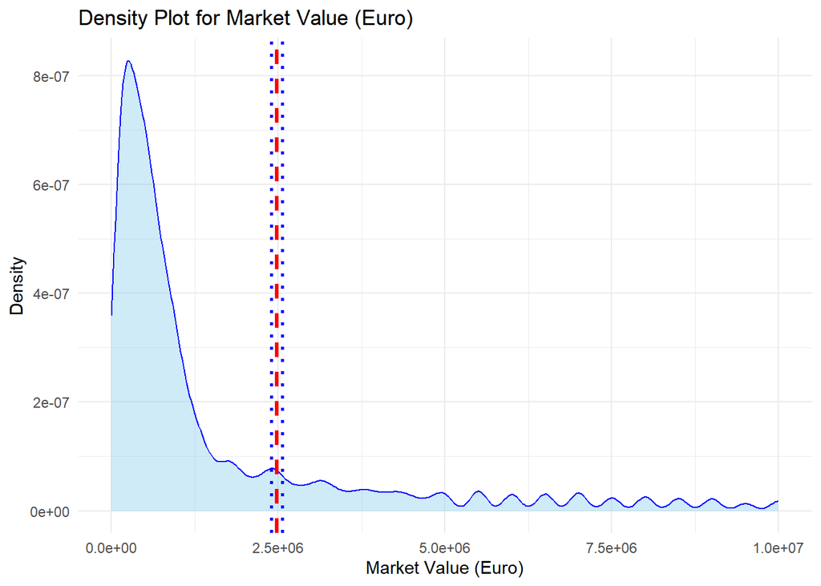

```r
# Calculate the means and confidence intervals for both variables
mean_value_euro <- mean(player_data$value_euro, na.rm = TRUE)
ci_value_euro <- t.test(player_data$value_euro)$conf.int

mean_stamina <- mean(player_data$stamina, na.rm = TRUE)
ci_stamina <- t.test(player_data$stamina)$conf.int

# Density plot (line graph) for value_euro with Confidence Interval
ggplot(player_data, aes(x = value_euro)) +
  geom_density(fill = "skyblue", alpha = 0.4, color = "blue") +  # Density line (smoothed)
  geom_vline(aes(xintercept = mean_value_euro), color = "red", linetype = "dashed", size = 1.2) +  # Mean line
  geom_vline(aes(xintercept = ci_value_euro[1]), color = "blue", linetype = "dotted", size = 1) +  # Lower CI bound
  geom_vline(aes(xintercept = ci_value_euro[2]), color = "blue", linetype = "dotted", size = 1) +  # Upper CI bound
  labs(title = "Density Plot for Market Value (Euro)",
       x = "Market Value (Euro)", y = "Density") +
  xlim(0, 1e7) +  # Set the limit for the x-axis
  theme_minimal()
```

### Observations

The density plot for market value exhibits a highly skewed distribution with a very pronounced peak near zero, suggesting that a significant number of players have a low market value. The tail extends into higher values, indicating that while most players are valued lower, there are a few with very high market values.

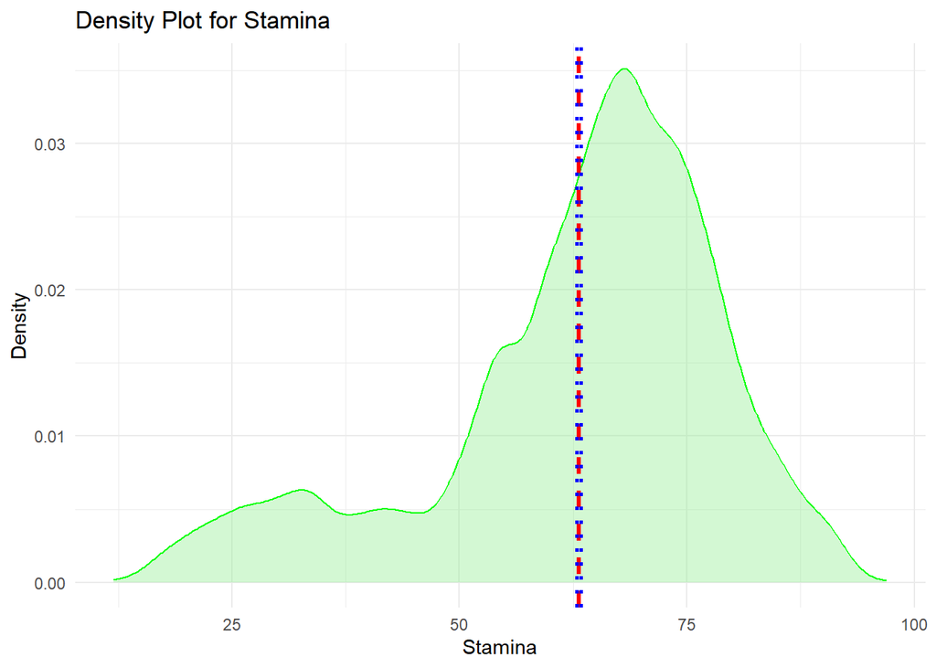

```r
# Density plot (line graph) for stamina with Confidence Interval
ggplot(player_data, aes(x = stamina)) +
  geom_density(fill = "lightgreen", alpha = 0.4, color = "green") +  # Density line (smoothed)
  geom_vline(aes(xintercept = mean_stamina), color = "red", linetype = "dashed", size = 1.2) +  # Mean line
  geom_vline(aes(xintercept = ci_stamina[1]), color = "blue", linetype = "dotted", size = 1) +  # Lower CI bound
  geom_vline(aes(xintercept = ci_stamina[2]), color = "blue", linetype = "dotted", size = 1) +  # Upper CI bound
  labs(title = "Density Plot for Stamina",
       x = "Stamina", y = "Density") +
  theme_minimal()
```

### Observations

END